# Table des matières

```python
import numpy as np                # linear algebra
import pandas as pd               # data frames
import matplotlib.pyplot as plt   # visualizations
import seaborn as sns             # visualizations
%matplotlib inline

import sklearn
from sklearn import decomposition
from sklearn import preprocessing
from sklearn import datasets
from sklearn.preprocessing import StandardScaler, scale
from sklearn.cluster import KMeans
from sklearn.decomposition import PCA
from sklearn.metrics import confusion_matrix, classification_report

import sklearn.metrics as sm

from functions_custom import *
```

```python
# sépatateurs milliers = , et 3 décimales
pd.options.display.float_format = '{:,.2f}'.format
```

# Mission 0

## Découverte du df

```python
# import des données
notes = pd.read_csv('data/notes.csv')
notes.index.names = ['id']
notes = notes[['is_genuine', 'length', 'diagonal', 'height_left', 'height_right',
               'margin_low', 'margin_up']]
notes.describe()
```

|  | length | diagonal | height_left | height_right | margin_low | margin_up |
| --- | --- | --- | --- | --- | --- | --- |
| count | 170.00 | 170.00 | 170.00 | 170.00 | 170.00 | 170.00 |
| mean | 112.57 | 171.94 | 104.07 | 103.93 | 4.61 | 3.17 |
| std | 0.92 | 0.31 | 0.30 | 0.33 | 0.70 | 0.24 |
| min | 109.97 | 171.04 | 103.23 | 103.14 | 3.54 | 2.27 |
| 25% | 111.85 | 171.73 | 103.84 | 103.69 | 4.05 | 3.01 |
| 50% | 112.84 | 171.94 | 104.06 | 103.95 | 4.45 | 3.17 |
| 75% | 113.29 | 172.14 | 104.29 | 104.17 | 5.13 | 3.33 |
| max | 113.98 | 173.01 | 104.86 | 104.95 | 6.28 | 3.68 |

```python
#export p_notes
notes.to_csv('data/p_notes.csv')
```

### Pandas Profiling Report

- Overview du dataframe
- Rapport détaillé des variables : statistiques, histogrammes, valeurs communes, outliers
- Analyse bivariées : corrélations
- valeurs manquantes
- Samples de 'head' et 'squew'

```python
import pandas_profiling
pandas_profiling.ProfileReport(notes)
```

[interactive chart not shown]

**Analyse**

- L’échantillon a 170 observations et 7 variables
- La variable is_genuine (bool) nous indique vrais et faux billets
- Les autres sont quantitatives et caratérisent chaque individu (mm)
- Les mesures sont sur des échelles différentes (cf margin vs diagonal, length, height)
- Les écart-types de lengh et margin_low sont élevés : forte dispersion des individus

### Analyse univariée

#### Wrangling

```python
# df de la variable boléenne
pk= notes[['is_genuine']].copy()
#export pk_notes
pk.to_csv('data/pk_notes.csv')
pk.head(1)
```

| id | is_genuine |
| --- | --- |
| 0 | True |

```python
# df de la variable boléenne
# melt : pivot des variables numériques dans les colonnes 'measure' et 'value'
pivot=notes.melt(id_vars=['is_genuine'], var_name='measure')
pivot.head(2)
```

|  | is_genuine | measure | value |
| --- | --- | --- | --- |
| 0 | True | length | 112.83 |
| 1 | True | length | 113.29 |

```python
# création d'un df par groupes de la variable 'measure'
p1=pivot.groupby('measure').get_group('length')
p2=pivot.groupby('measure').get_group('diagonal')
p3=pivot.groupby('measure').get_group('height_left')
p4=pivot.groupby('measure').get_group('height_right')
p5=pivot.groupby('measure').get_group('margin_low')
p6=pivot.groupby('measure').get_group('margin_up')
```

```python
# affichage par variable numérique
p1.head(1)
```

|  | is_genuine | measure | value |
| --- | --- | --- | --- |
| 0 | True | length | 112.83 |

#### Boxplots

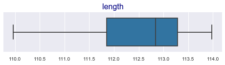

```python
# 'length'
sns.set_style("darkgrid")
plt.figure(figsize=(8,1.5))

g=sns.boxplot(data=p1[['value']],width =0.7,orient="h")
g.set(yticklabels=[])

plt.title("length", fontsize=16, color = 'navy')
plt.savefig('img/P6.0_bp_length.png', dpi=120, bbox_inches='tight')
plt.show()
plt.close()
```

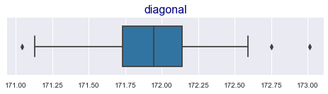

```python
# 'diagonal'
sns.set_style("darkgrid")
plt.figure(figsize=(8,1.5))

g=sns.boxplot(data=p2[['value']],width =0.7,orient="h")
g.set(yticklabels=[])

plt.title("diagonal", fontsize=16, color = 'navy')
plt.savefig('img/P6.0_bp_diagonal.png', dpi=120, bbox_inches='tight')
plt.show()
plt.close()
```

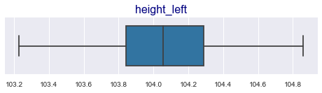

```python
# 'height_left'
sns.set_style("darkgrid")
plt.figure(figsize=(8,1.5))

g=sns.boxplot(data=p3[['value']],width =0.7,orient="h")
g.set(yticklabels=[])

plt.title("height_left", fontsize=16, color = 'navy')
plt.savefig('img/P6.0_bp_height_left.png', dpi=120, bbox_inches='tight')
plt.show()
plt.close()
```

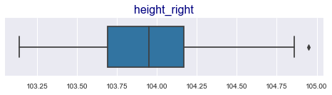

```python
# 'height_right'
sns.set_style("darkgrid")
plt.figure(figsize=(8,1.5))

g=sns.boxplot(data=p4[['value']],width =0.7,orient="h")
g.set(yticklabels=[])

plt.title("height_right", fontsize=16, color = 'navy')
plt.savefig('img/P6.0_bp_height_right.png', dpi=120, bbox_inches='tight')
plt.show()
plt.close()
```

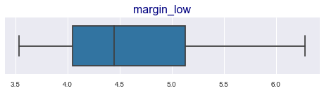

```python
# 'margin_low'
sns.set_style("darkgrid")
plt.figure(figsize=(8,1.5))

g=sns.boxplot(data=p5[['value']], width =0.7,orient="h")
g.set(yticklabels=[])

plt.title("margin_low", fontsize=16, color = 'navy')
plt.savefig('img/P6.0_bp_margin_low.png', dpi=120, bbox_inches='tight')
plt.show()
plt.close()
```

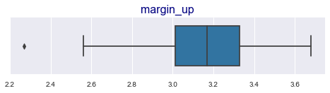

```python
# 'margin_up'
sns.set_style("darkgrid")
plt.figure(figsize=(8,1.5))

g=sns.boxplot(data=p6[['value']],width =0.7,orient="h")
g.set(yticklabels=[])

plt.title("margin_up", fontsize=16, color = 'navy')
plt.savefig('img/P6.0_bp_margin_up.png', dpi=120, bbox_inches='tight')
plt.show()
plt.close()
```

### Analyse bivariée : swarmplots

#### length

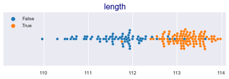

```python
# figure
sns.set_style("darkgrid")
plt.figure(figsize=(8,2))
plt.title("length", fontsize=16, color = 'navy')

# swarmplot 'length'
g=sns.swarmplot(x='value', y='measure', data=p1, hue='is_genuine')
g.set(yticklabels=[])
plt.xlim(109.1, 114.1)
plt.xlabel('')
plt.ylabel('')
plt.legend(loc='upper left')

plt.savefig('img/P6.0_sp_length.png', dpi=120, bbox_inches='tight')
plt.show()
plt.close()
```

#### diagonal

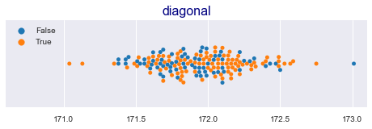

```python
# figure
sns.set_style("darkgrid")
plt.figure(figsize=(8,2))
plt.title("diagonal", fontsize=16, color = 'navy')

# swarmplot 'diagonal'
g=sns.swarmplot(x='value', y='measure', data=p2, hue='is_genuine')
g.set(yticklabels=[])
plt.xlim(170.6, 173.1)
plt.xlabel('')
plt.ylabel('')
plt.legend(loc='upper left')

plt.savefig('img/P6.0_sp_diagonal.png', dpi=120, bbox_inches='tight')
plt.show()
plt.close()
```

#### height_left

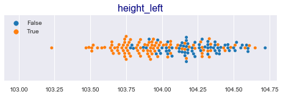

```python
# figure
sns.set_style("darkgrid")
plt.figure(figsize=(8,2))
plt.title("height_left", fontsize=16, color = 'navy')

# swarmplot 'height_left'
g=sns.swarmplot(x='value', y='measure', data=p3, hue='is_genuine')
g.set(yticklabels=[])
plt.xlim(102.9, 104.8)
plt.xlabel('')
plt.ylabel('')
plt.legend(loc='upper left')

plt.savefig('img/P6.0_sp_height_left.png', dpi=120, bbox_inches='tight')
plt.show()
plt.close()
```

#### height_right

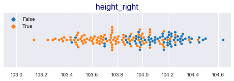

```python
# figure
sns.set_style("darkgrid")
plt.figure(figsize=(8,2))

# swarmplot 'height_right'
g=sns.swarmplot(x='value', y='measure', data=p4, hue='is_genuine')
g.set(yticklabels=[])

plt.title("height_right", fontsize=16, color = 'navy')
plt.xlim(102.9, 104.7)
plt.xlabel('')
plt.ylabel('')
plt.legend(loc='upper left')

plt.savefig('img/P6.0_sp_height_right.png', dpi=120, bbox_inches='tight')
plt.show()
plt.close()
```

#### margin_low

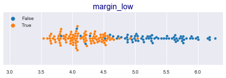

```python
# figure
sns.set_style("darkgrid")
plt.figure(figsize=(8,2))
plt.title("margin_low", fontsize=16, color = 'navy')

# swarmplot 'margin_low'
g=sns.swarmplot(x='value', y='measure', data=p5, hue='is_genuine')
g.set(yticklabels=[])
plt.xlim(2.9, 6.4)
plt.xlabel('')
plt.ylabel('')
plt.legend(loc='upper left')

plt.savefig('img/P6.0_sp_margin_low.png', dpi=120, bbox_inches='tight')
plt.show()
plt.close()
```

#### margin_up

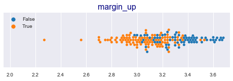

```python
# figure
sns.set_style("darkgrid")
plt.figure(figsize=(8,2))
plt.title("margin_up", fontsize=16, color = 'navy')

# swarmplot 'margin_up'
g=sns.swarmplot(x='value', y='measure', data=p6, hue='is_genuine')
g.set(yticklabels=[])
plt.xlim(1.95, 3.73)
plt.xlabel('')
plt.ylabel('')
plt.legend(loc='upper left')

plt.savefig('img/P6.0_sp_margin_up.png', dpi=120, bbox_inches='tight')
plt.show()
plt.close()
```

### Analyse bivariée : répartition de 'True' et 'False'

#### length

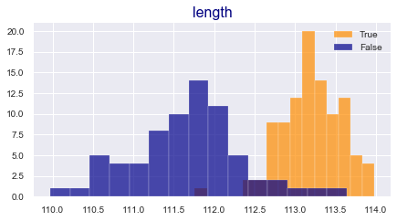

```python
# prépa du df
X=p1[['is_genuine','value']].copy()

x1 = X.loc[X['is_genuine'] ==True]
x2 = X.loc[X['is_genuine'] ==False]

# diagramme
plt.figure(figsize=(7,3.5))
sns.set_style('darkgrid')

sns.distplot( x1["value"] , kde=False, color="darkorange", label="True", bins=15, hist_kws=dict(alpha=0.7))
sns.distplot( x2["value"] , kde=False, color="darkblue", label="False", bins=15, hist_kws=dict(alpha=0.7))

plt.title('length', fontsize=16, color='navy')
plt.legend()
plt.xlabel('')
plt.savefig('img/P6.0_ht_length.png', dpi=120, bbox_inches='tight')
plt.show()
plt.close()
```

#### diagonal

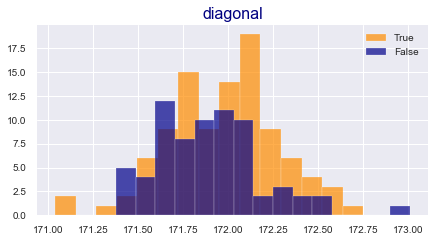

```python
# prépa du df
X=p2[['is_genuine','value']].copy()

x1 = X.loc[X['is_genuine'] ==True]
x2 = X.loc[X['is_genuine'] ==False]

# diagramme
plt.figure(figsize=(7,3.5))
sns.set_style('darkgrid')

sns.distplot( x1["value"] , kde=False, color="darkorange", label="True",bins=15, hist_kws=dict(alpha=0.7))
sns.distplot( x2["value"] , kde=False, color="darkblue", label="False", bins=15, hist_kws=dict(alpha=0.7))

plt.title('diagonal', fontsize=16, color='navy')
plt.legend()
plt.xlabel('')
plt.savefig('img/P6.0_ht_diagonal.png', dpi=120, bbox_inches='tight')
plt.show()
plt.close()
```

#### height_left

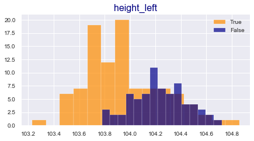

```python
# prépa du df
X=p3[['is_genuine','value']].copy()

x1 = X.loc[X['is_genuine'] ==True]
x2 = X.loc[X['is_genuine'] ==False]

# diagramme
plt.figure(figsize=(7,3.5))
sns.set_style('darkgrid')

sns.distplot( x1["value"] , kde=False, color="darkorange", label="True",bins=15, hist_kws=dict(alpha=0.7))
sns.distplot( x2["value"] , kde=False, color="darkblue", label="False", bins=15, hist_kws=dict(alpha=0.7))

plt.title('height_left', fontsize=16, color='navy')
plt.legend()
plt.xlabel('')
plt.savefig('img/P6.0_ht_height_left.png', dpi=120, bbox_inches='tight')
plt.show()
plt.close()
```

#### height_right

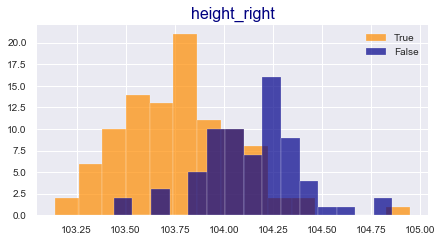

```python
# prépa du df
X=p4[['is_genuine','value']].copy()

x1 = X.loc[X['is_genuine'] ==True]
x2 = X.loc[X['is_genuine'] ==False]

# diagramme
plt.figure(figsize=(7,3.5))
sns.set_style('darkgrid')

sns.distplot( x1["value"] , kde=False, color="darkorange", label="True", bins=15, hist_kws=dict(alpha=0.7))
sns.distplot( x2["value"] , kde=False, color="darkblue", label="False", bins=15, hist_kws=dict(alpha=0.7))

plt.title('height_right', fontsize=16, color='navy')
plt.legend()
plt.xlabel('')
plt.savefig('img/P6.0_ht_height_right.png', dpi=120, bbox_inches='tight')
plt.show()
plt.close()
```

#### margin_low

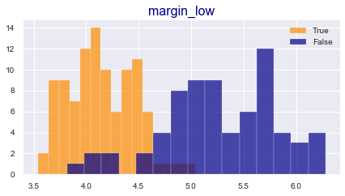

```python
# prépa du df
X=p5[['is_genuine','value']].copy()

x1 = X.loc[X['is_genuine'] ==True]
x2 = X.loc[X['is_genuine'] ==False]

# diagramme
plt.figure(figsize=(7,3.5))
sns.set_style('darkgrid')

sns.distplot( x1["value"] , kde=False, color="darkorange", label="True", bins=15, hist_kws=dict(alpha=0.7))
sns.distplot( x2["value"] , kde=False, color="darkblue", label="False", bins=15, hist_kws=dict(alpha=0.7))

plt.title('margin_low', fontsize=16, color='navy')
plt.legend()
plt.xlabel('')
plt.savefig('img/P6.0_ht_margin_low.png', dpi=120, bbox_inches='tight')
plt.show()
plt.close()
```

#### margin_up

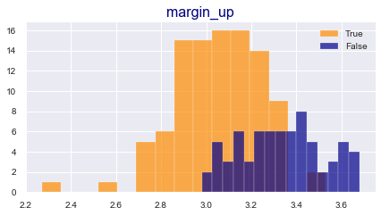

```python
# prépa du df
X=p6[['is_genuine','value']].copy()

x1 = X.loc[X['is_genuine'] ==True]
x2 = X.loc[X['is_genuine'] ==False]

# diagramme
plt.figure(figsize=(7,3.5))
sns.set_style('darkgrid')

sns.distplot( x1["value"] , kde=False, color="darkorange", label="True", bins=15, hist_kws=dict(alpha=0.7))
sns.distplot( x2["value"] , kde=False, color="darkblue", label="False", bins=15, hist_kws=dict(alpha=0.7))

plt.title('margin_up', fontsize=16, color='navy')
plt.legend()
plt.xlabel('')
plt.savefig('img/P6.0_ht_margin_up.png', dpi=120, bbox_inches='tight')
plt.show()
plt.close()
```

# Mission 1

## ACP

### Préparation des données et calculs

```python
# rappel du dataframe
data=pd.read_csv('data/p_notes.csv', index_col=0)
data.drop(['is_genuine'], axis=1, inplace = True)
data.head(1)
```

| id | length | diagonal | height_left | height_right | margin_low | margin_up |
| --- | --- | --- | --- | --- | --- | --- |
| 0 | 112.83 | 171.81 | 104.86 | 104.95 | 4.52 | 2.89 |

```python
# préparation des données pour l'ACP
X = data.values
names = data.index
features = data.columns

#transformation–centrage-réduction
X_scaled = preprocessing.StandardScaler().fit_transform(X)
```

```python
# df données centrées-réduites
data_cr = pd.DataFrame(X_scaled, columns = ['length', 'diagonal', 'height_left', 'height_right', 'margin_low', 'margin_up'])
data_cr.index.name='id'
data_cr.to_csv('data/notes_cr.csv')
data_cr.head(1)
```

| id | length | diagonal | height_left | height_right | margin_low | margin_up |
| --- | --- | --- | --- | --- | --- | --- |
| 0 | 0.28 | -0.43 | 2.67 | 3.10 | -0.13 | -1.19 |

```python
# nombre de composantes
n_comp = 6

# Calcul des composantes principales
pca = decomposition.PCA(svd_solver='full', n_components=n_comp)
pca.fit(X_scaled)
```

```
PCA(copy=True, iterated_power='auto', n_components=6, random_state=None,
    svd_solver='full', tol=0.0, whiten=False)
```

### Scree plot et variance

```python
def display_scree_plot(pca):
    sns.set_style("whitegrid")
    plt.figure(figsize=(8,6))

    scree = pca.explained_variance_ratio_*100
    plt.bar(np.arange(len(scree))+1, scree)
    plt.plot(np.arange(len(scree))+1, scree.cumsum(),c="red",marker='o')
    plt.xlim(0.5, 6.5)
    plt.ylim(0, 102)
    plt.xlabel("rang de l'axe d'inertie", size=13, fontweight='bold')
    plt.ylabel("pourcentage d'inertie", size=13, fontweight='bold')
    plt.title("Eboulis des valeurs propres", color='navy', size=16)
    plt.axvline(2, linestyle='dashed', color = 'grey')
    plt.show(block=False)
```

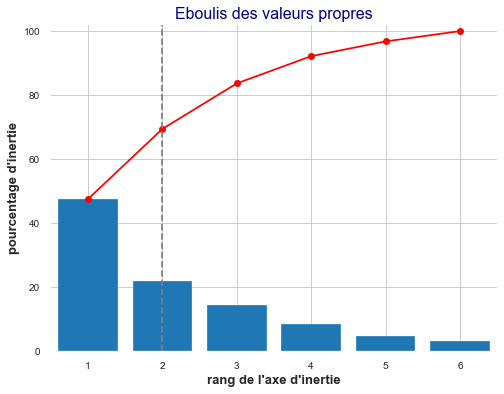

```python
# Eboulis des valeurs propres
display_scree_plot(pca)

# plt.savefig('img/P6.1_scree_plot.png', dpi=120, bbox_inches='tight')
plt.show()
plt.close()
```

```python
# Proportion de variance expliquée
ve=pca.explained_variance_ratio_ *100
# Proportion de variance cumulée
vc=np.cumsum(pca.explained_variance_ratio_)*100

var = pd.DataFrame(data=[ve, vc],index =['Variance expliquée', 'Variance cumulée'])
var.columns=['CP1','CP2','CP3','CP4','CP5','CP6']
var
```

|  | CP1 | CP2 | CP3 | CP4 | CP5 | CP6 |
| --- | --- | --- | --- | --- | --- | --- |
| Variance expliquée | 47.45 | 21.96 | 14.23 | 8.53 | 4.61 | 3.22 |
| Variance cumulée | 47.45 | 69.41 | 83.64 | 92.17 | 96.78 | 100.00 |

**Analyse**

- Le coude apparaît dès la deuxième composante.
- Le premier plan factoriel CP1-CP2 représente 69,4 % variance cumulée
- Il est légitime de se poser la question de travailler avec une représentation en 3D, en ajoutant CP3 (83,6 % variance cumulée)
- Nous nous en tenons aux 2 dimensions offrant la meilleure variance cumulée

### Variables

#### Cercle des corrélations (CP1-CP2)

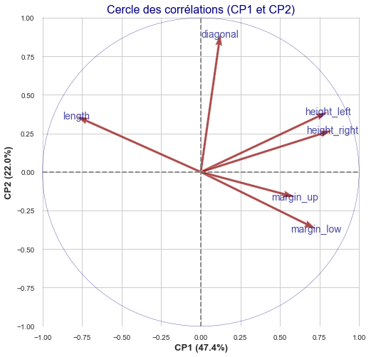

```python
sns.set_style("whitegrid")

# cercle des corrélations
pcs = get_correlation(pca, X_scaled)
display_circles(pcs, n_comp, pca, [(0,1)], labels = np.array(features))

# plt.savefig('img/P6.1_corr_circle.png', dpi=120, bbox_inches='tight')
plt.show()
plt.close()
```

**Analyse**

- Les variables heigh_left, heigh_right et margin_low sont positivement très biens représentées sur l'axe F1.
- La variable length est négativement très bien représentée sur l'axe F1.
- margin_low et margin_up sont anticorrélées à length
- La variable diagonal est la mieux représentée sur l'axe F2
- diagonal n'est pas corrélée à margin_up et margin_low, et faiblement à length

#### Contribution des variables sur CP1-CP2

```python
contrib_var = pca.components_.T * np.sqrt(pca.explained_variance_)
df_contrib_var = pd.DataFrame(data = contrib_var, columns = ['CP1','CP2','CP3','CP4','CP5','CP6'],index=data.columns)
df_contrib_var.drop(['CP3','CP4','CP5','CP6'], axis=1, inplace = True)
# df_contrib_var
```

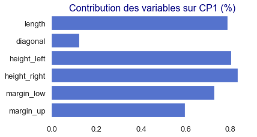

```python
df_contrib_var_ind=df_contrib_var.abs().reset_index()
sns.set_style('white')

f,ax = plt.subplots(figsize=(6,3.2))
contrib_var_plot_1 = sns.barplot(x='CP1',y='index',data=df_contrib_var_ind,color='royalblue')


ax.set_title('Contribution des variables sur CP1 (%)', fontsize=16,color='navy')
ax.set_ylabel('')
ax.set_xlabel('')
ax.tick_params(axis='x', labelsize=13)
ax.tick_params(axis='y', labelsize=13)
plt.xlim(0, 0.9)

plt.savefig('img/P6.1_cv_CP1.png', dpi=120, bbox_inches='tight')
```

```python
df_contrib_var
```

|  | CP1 | CP2 |
| --- | --- | --- |
| length | -0.79 | 0.36 |
| diagonal | 0.12 | 0.90 |
| height_left | 0.80 | 0.39 |
| height_right | 0.83 | 0.27 |
| margin_low | 0.73 | -0.37 |
| margin_up | 0.60 | -0.16 |

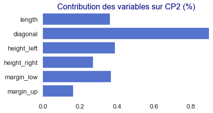

```python
df_contrib_var_ind=df_contrib_var.abs().reset_index()
sns.set_style('white')

f,ax = plt.subplots(figsize=(6,3.2))
contrib_var_plot_2 = sns.barplot(x='CP2',y='index',data=df_contrib_var_ind, color='royalblue')
ax.set_title('Contribution des variables sur CP2 (%)', fontsize=16, color='navy')
ax.set_ylabel('')
ax.set_xlabel('')
ax.tick_params(axis='x', labelsize=13)
ax.tick_params(axis='y', labelsize=13)
plt.xlim(0, 0.9)

plt.savefig('img/P6.1_cv_CP2.png', dpi=120, bbox_inches='tight')
```

#### Qualité de représentation des variables (COS²)

```python
format_dict = {'COS2_1':'{:.2f}','COS2_2':'{:.2f}',}

cos2var = pcs.T**2
cos2_var = pd.DataFrame(cos2var, index=features,
                        columns=['COS2_'+str(i + 1) for i in range(n_comp)])
cos2_var.drop(['COS2_3','COS2_4','COS2_5','COS2_6'], axis=1, inplace = True)
cos2_var['COS2_1']=cos2_var['COS2_1']*100
cos2_var['COS2_2']=cos2_var['COS2_2']*100
cos2_var
(cos2_var.style.format(format_dict)
 .bar('COS2_1', color='peachpuff', align='zero')
 .bar('COS2_2', color='lightblue', align='zero')
 .set_caption('Qualité de représentation des variables (cos²)')
)
```

Qualité de représentation des variables (cos²)

|  | COS2_1 | COS2_2 |
| --- | --- | --- |
| length | 61.66 | 13.03 |
| diagonal | 1.53 | 80.08 |
| height_left | 64.37 | 15.16 |
| height_right | 68.86 | 7.31 |
| margin_low | 52.89 | 13.54 |
| margin_up | 35.38 | 2.62 |

### Centroides des clusters

```python
# création du df
centroides = data.groupby(pk['is_genuine']).mean()
centroides
```

| is_genuine | length | diagonal | height_left | height_right | margin_low | margin_up |
| --- | --- | --- | --- | --- | --- | --- |
| False | 111.66 | 171.89 | 104.23 | 104.15 | 5.28 | 3.33 |
| True | 113.21 | 171.98 | 103.95 | 103.78 | 4.14 | 3.06 |

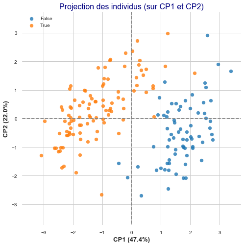

```python
sns.set_style('whitegrid')
# clusters auxquels appartiennent les pays
statut = [pk.loc[statut, 'is_genuine'] for statut in data.index]

# Projection des individus
X_projected = pca.transform(X_scaled)
display_factorial_planes(X_projected, n_comp, pca, [(0,1)], labels = None,
illustrative_var = statut, alpha = 0.8)

# plt.savefig('img/P6.1_proj_indiv.png', dpi=120, bbox_inches='tight')
plt.show()
plt.close()
```

**Analyse**  
Sur le premier plan on peut distinguer 3 zones :

- Sous -0,6 il est presque certain d’avoir des vrais billets
- Au-dessus de 1,0, la probabilité est élevée d’avoir de faux billets
- Entre -0,6 et 1,0 cela peut être un vrai ou un faux billet, à moins de tenir compte de la distribution sur le 2e plan  
  En effet, les vrais billets sur cette zone sont plutôt vrais au-dessus de -0,6 sur CP2 et faux en-dessous

### Individus

#### Représentation des individus

```python
# création du df de représentation sur les 6 plans
notes_pca = pd.DataFrame(X_projected, index=data.index, columns = ['CP1','CP2','CP3','CP4','CP5','CP6'])
notes_pca.to_csv('data/notes_pca.csv', index = False)
notes_pca.head(1)
```

| id | CP1 | CP2 | CP3 | CP4 | CP5 | CP6 |
| --- | --- | --- | --- | --- | --- | --- |
| 0 | 2.15 | 1.60 | 1.79 | 2.43 | 0.70 | -1.27 |

#### Contribution des individus dans l'inertie totale

```python
#contribution des individus dans l'inertie totale
di = np.sum(X_scaled**2,axis=1)
# Création du data frame
contrib = pd.DataFrame(di, index=data.index, columns=['d_i'])
contrib.sort_values('d_i', axis = 0, ascending = False, inplace = True)
contrib.head()
```

| id | d_i |
| --- | --- |
| 166 | 20.63 |
| 0 | 18.41 |
| 4 | 18.04 |
| 122 | 16.79 |
| 39 | 15.05 |

cf outliers dans la mission 0

#### Contribution des individus sur CP1-CP2

```python
# dimensions de X
(n, p) = data.shape

# calcul des valeurs propres à partir des valeurs singulières
eigval = pca.singular_values_**2/n

# contribution aux axes
ctr = X_projected**2
for j in range(n_comp):
    ctr[:,j] = ctr[:,j]/(n*eigval[j])

ctr_indiv = pd.DataFrame(ctr, index=data.index,
                         columns=['CTR_'+str(i + 1) for i in range(n_comp)])

ctr_indiv.drop(['CTR_3','CTR_4','CTR_5','CTR_6'], axis=1, inplace = True)
ctr_indiv['CTR_1']=ctr_indiv['CTR_1']*100
ctr_indiv['CTR_2']=ctr_indiv['CTR_2']*100
ctr_indiv.head(2)
```

| id | CTR_1 | CTR_2 |
| --- | --- | --- |
| 0 | 0.96 | 1.14 |
| 1 | 0.92 | 0.12 |

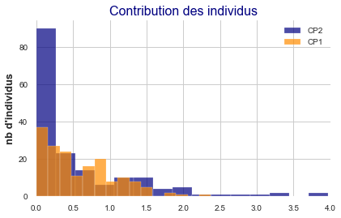

```python
# prépa du df
X=ctr_indiv.copy()

x1 = X.CTR_1
x2 = X.CTR_2

# diagramme
plt.figure(figsize=(6.5,4))
sns.set_style('whitegrid')

sns.distplot( x2, kde=False, color="navy", label="CP2", bins=15, hist_kws=dict(alpha=0.7))
sns.distplot( x1, kde=False, color="darkorange", label="CP1", bins=15, hist_kws=dict(alpha=0.7))

# custom
plt.title('Contribution des individus', fontsize=16, color='navy')
plt.xlim(0, 4)
plt.legend()
plt.xlabel('')
plt.ylabel("nb d'individus", size=13, fontweight='bold')

plt.savefig('img/P6.1_contr_ind.png', dpi=120, bbox_inches='tight')
plt.show()
plt.close()
```

#### Qualité de représentation des individus (COS²)

```python
cos2 = X_projected**2

for j in range(n_comp):
    cos2[:,j] = cos2[:,j]/di

cos2_indiv = pd.DataFrame(cos2, index=data.index,
                          columns=['COS2_'+str(i + 1) for i in range(n_comp)])

cos2_indiv.drop(['COS2_3','COS2_4','COS2_5','COS2_6'], axis=1, inplace = True)
cos2_indiv.head(2)
```

| id | COS2_1 | COS2_2 |
| --- | --- | --- |
| 0 | 0.25 | 0.14 |
| 1 | 0.82 | 0.05 |

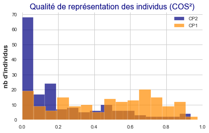

```python
# prépa du df
X=cos2_indiv.copy()

x1 = X.COS2_1
x2 = X.COS2_2

# diagramme
plt.figure(figsize=(6.5,4))
sns.set_style('whitegrid')

sns.distplot( x2, kde=False, color="navy", label="CP2", bins=15, hist_kws=dict(alpha=0.7))
sns.distplot( x1, kde=False, color="darkorange", label="CP1", bins=15, hist_kws=dict(alpha=0.7))

# custom
plt.title('Qualité de représentation des individus (COS²)', fontsize=16, color='navy')
plt.legend()
plt.xlabel('')
plt.ylabel("nb d'individus", size=13, fontweight='bold')
plt.xlim(0, 1)

plt.savefig('img/P6.1_cos2_ind.png', dpi=120, bbox_inches='tight')
plt.show()
plt.close()
```

# Mission 2

Appliquer un algorithme de classification, puis analysez le résultat obtenu.

Visualisez la partition obtenue dans le premier plan factoriel de l'ACP, puis analysez-la.

## k-means

### Rappel du df 'notes' originel et du df 'notes' centré-réduit

```python
# df 'notes' variables numériques originel
km = pd.read_csv('data/p_notes.csv', index_col=0)
km.drop(['is_genuine'], axis=1, inplace = True)

km.head(1)
```

| id | length | diagonal | height_left | height_right | margin_low | margin_up |
| --- | --- | --- | --- | --- | --- | --- |
| 0 | 112.83 | 171.81 | 104.86 | 104.95 | 4.52 | 2.89 |

- Les variables ont la même unité de mesure, mais les écarts de mesure sont élevés
- Il faut centrer-réduire

```python
# df 'notes' variables centrées-réduites
X_scaled=pd.read_csv('data/notes_cr.csv', index_col =0)
X_scaled.head(1)
```

| id | length | diagonal | height_left | height_right | margin_low | margin_up |
| --- | --- | --- | --- | --- | --- | --- |
| 0 | 0.28 | -0.43 | 2.67 | 3.10 | -0.13 | -1.19 |

### k-means sur les données centrées-réduites

```python
#k-means sur les données centrées et réduites
from sklearn import cluster
kmeans = cluster.KMeans(n_clusters=2)
kmeans.fit(X_scaled)
```

```
KMeans(algorithm='auto', copy_x=True, init='k-means++', max_iter=300,
       n_clusters=2, n_init=10, n_jobs=None, precompute_distances='auto',
       random_state=None, tol=0.0001, verbose=0)
```

```python
# cluster prédit pour chaque variable
identified_clusters = kmeans.fit_predict(X_scaled)
identified_clusters
```

```
array([0, 1, 1, 1, 1, 0, 1, 1, 1, 0, 0, 1, 1, 1, 1, 1, 1, 1, 1, 1, 1, 1,
       1, 1, 1, 1, 1, 1, 1, 1, 1, 1, 1, 1, 1, 1, 1, 1, 1, 1, 1, 1, 1, 1,
       1, 1, 1, 1, 1, 1, 1, 1, 1, 1, 1, 1, 1, 1, 1, 1, 1, 1, 1, 1, 1, 0,
       1, 1, 1, 0, 1, 1, 1, 1, 1, 1, 1, 1, 1, 1, 1, 1, 1, 1, 0, 1, 1, 1,
       1, 1, 1, 1, 1, 1, 1, 1, 0, 1, 1, 1, 0, 0, 0, 0, 0, 0, 0, 0, 0, 0,
       0, 0, 0, 0, 0, 0, 0, 0, 0, 0, 0, 0, 0, 0, 0, 0, 0, 0, 0, 0, 0, 0,
       0, 0, 0, 0, 0, 0, 0, 0, 0, 0, 0, 0, 1, 0, 0, 0, 0, 0, 0, 0, 0, 0,
       0, 0, 0, 0, 0, 0, 0, 0, 0, 0, 0, 0, 0, 0, 0, 0])
```

```python
# distances aux centres de classes des observations
k2=kmeans.transform(X_scaled)
k2
```

[output not shown]

[output cut: 115 more lines]

```
       [1.75228792, 3.77099046],
       [2.82461446, 3.46264402],
       [1.81175735, 3.32600429],
       [2.45685687, 4.74192817],
       [2.61164896, 4.61656208],
       [3.5564096 , 4.14804088],
       [1.83445218, 3.58557586],
       [1.45983252, 3.2404967 ],
       [1.26959227, 3.67302681],
       [2.03868062, 3.55217601],
       [1.53015081, 4.03871907],
       [4.05178888, 5.32294051],
       [2.20201627, 3.9836736 ],
       [1.78143344, 2.82180286],
       [1.55977547, 3.46764761]])
```

```python
# pandas DataFrame de clusters
pkc = pd.DataFrame(identified_clusters, columns = ['clust'])
pkc.index.name='id'

pkc['clust'] = pkc['clust'].astype('bool')

pkc.head(2)
```

| id | clust |
| --- | --- |
| 0 | False |
| 1 | True |

### Projection des individus sur CP1-CP2

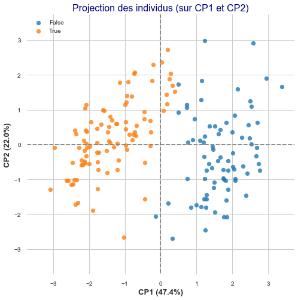

```python
# cluster auxquels appartiennent les billets
statut = [pkc.loc[statut, 'clust'] for statut in data.index]

# projection des individus
X_projected = pca.transform(X_scaled)
display_factorial_planes(X_projected, n_comp, pca, [(0,1)],
                         illustrative_var = statut, alpha = 0.8)

#plt.savefig('img/P6.2_proj_indiv.png', dpi=120, bbox_inches='tight')
plt.show()
plt.close()
```

**Analyse**

- L’apprentissage non-supervisé K-means (avec K=2 clusters) est une méthode qui offre rapidement une solution - pas nécessairement optimale, par son appartenance à une classe de problèmes donnés déjà identifiés (heuristique)
- Notre modèle, projeté sur les plans factoriels 1 et 2 propose une solution de classement proche de celle fournie par le statut réel des individus (is_genuine) sur les composantes 1 et 2

```python
#librairie pour évaluation des partitions
from sklearn import metrics

#utilisation de la métrique "silhouette"
#faire varier le nombre de clusters de 2 à 10
res = np.arange(6,dtype="double")
for k in np.arange(6):
    km = cluster.KMeans(n_clusters=k+2)
    km.fit(X_scaled)
    res[k] = metrics.silhouette_score(X_scaled,km.labels_)
print(res)
```

```
[0.35143613 0.29985971 0.25460062 0.20204616 0.20504894 0.20466468]
```

### confusion matrix

```python
cma = pd.read_csv('data/p_notes.csv', index_col =0)
cma['is_genuine'] = (cma['is_genuine'] == True).astype(int)
cma.head(1)
```

| id | is_genuine | length | diagonal | height_left | height_right | margin_low | margin_up |
| --- | --- | --- | --- | --- | --- | --- | --- |
| 0 | 1 | 112.83 | 171.81 | 104.86 | 104.95 | 4.52 | 2.89 |

```python
confusion_matrix = pd.crosstab(pk['is_genuine'], pkc['clust'], rownames=['Actual'], colnames=['Predicted'])
confusion_matrix
```

| Predicted Actual | False | True |
| --- | --- | --- |
| False | 69 | 1 |
| True | 8 | 92 |

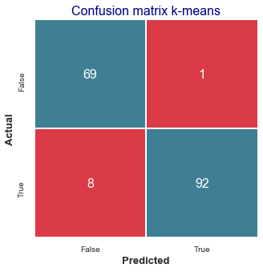

```python
plt.figure(figsize=(5,5))

sns.heatmap(confusion_matrix, annot=True, annot_kws={"size": 16},
            cmap=sns.diverging_palette(10, 220, sep=80, n=2),linewidths=1, linecolor='white',cbar=False)

plt.title('Confusion matrix k-means', fontsize=16, color='navy')
plt.xlabel('Predicted', size=13, fontweight='bold')
plt.ylabel('Actual', size=13, fontweight='bold')

plt.savefig('img/P6.2_conf_matrix.png', dpi=120, bbox_inches='tight')
plt.show()
plt.close()
```

**Analyse**

- La matrice de confusion nous montre que sur 100 vrais billets 92 ont été identifies comme vrais et 8 comme faux par l’algorithme
- Sur 70 faux billets, il en classe 69 comme faux et un comme vrai
- On pourrait en déduire que les faux billets sont plutôt mieux identifiés que les vrais par cette méthode